# PCA

### Principal component analysis

### Présentation des données:

```
##   IDEN.C.5 SEXE AGE TAILLE POIDS TAILLE.1 POULS SYS DIA CHOL  IMC JMBG
## 1    I0001    0  58  179.8  76.7     90.6    68 125  78  522 23.8 42.5
## 2    I0002    0  22  168.1  65.4     78.1    64 107  54  127 23.2 40.2
## 3    I0003    0  32  182.1  81.3     96.5    88 126  81  740 24.6 44.4
## 4    I0004    0  31  174.5  79.7     87.7    72 110  68   49 26.2 42.8
## 5    I0005    0  28  171.7  69.2     87.1    64 110  66  230 23.5 40.0
##   COUD POIGN BRAS
## 1  7.7   6.4 31.9
## 2  7.6   6.2 31.0
## 3  7.3   5.8 32.7
## 4  7.5   5.9 33.4
## 5  7.1   6.0 30.1
```

##### Les données se composent de 80 individus décrits sur 14 variables, 1 variable qualitative: le sexe et 13 variables quantitatives, sur différentes échelles:

##### -L’age

##### -Le poids

##### -Le tour de taille

##### -Le pouls

##### -La diastole

##### -La systole

##### -Le cholesterol

##### -L’IMC

##### -La longueur de la jambe gauche

##### -La largeur du coude

##### -La largeur du poignet

##### -La circonférence du bras.

### Choix du nombre d’Axes:

```
## [1] 6.0247974 2.2676335 1.1695556 0.9661908 0.8099068 0.6170705
```

##### Les 6 premières valeurs propres avec la régle de Kaiser indiquent qu’il faut garder les 3 premiers axes factoriels, cependant pour des raisons de visibilité, j’utiliserai le critère du coude pour ne garder que les 2 premières composantes principales.

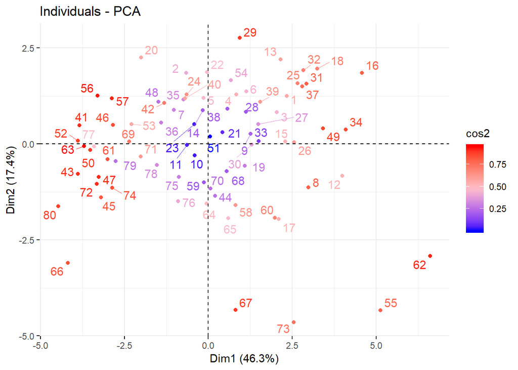

##### Le premier plan factoriel conserve 64% de l’inertie du nuage, 46% de l’inertie du nuage est conservé par le premier axe, une structure importante des données devrait donc se manifester sur cet axe.

##### Le nuage des projections des individus est assez homogène et centré. Les individus qui contribuent le plus à la construction des axes (les plus éloignés de l’origine) sont bien représentés(il n’est pas nécessaire d’en mettre en variables suplémentaires).

### Interprétation des Axes:

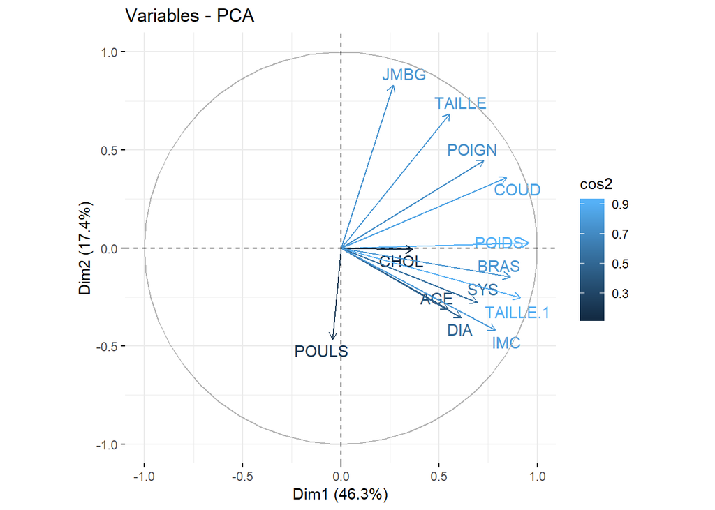

##### On observe que beaucoup de variables ont un angle trés faibles les unes avec les autres, elles sont donc fortement corrélées positivement entre elles et sont bien représentées (elles sont proches du cercle et logiquement, ont un cos2 élevé) . De plus peu de variables ne sont pas corrélées entre elles, seule les variables taille de la jambe gauche (JMBG) et taille ont une trés faible corrélation avec les variables IMC et Tour de taille (taille1), Mais elles restent légérement corrélés avec l’axe 1, ce qui explique qu’il conserve une grande part de l’inertie.

##### Les Variables Poids, Bras, Taille1, IMC sont fortement corrélées positivement entre elles et contribuent majoritairement à la construction de l’axe 1, comme l’illustre le graphique suivant:

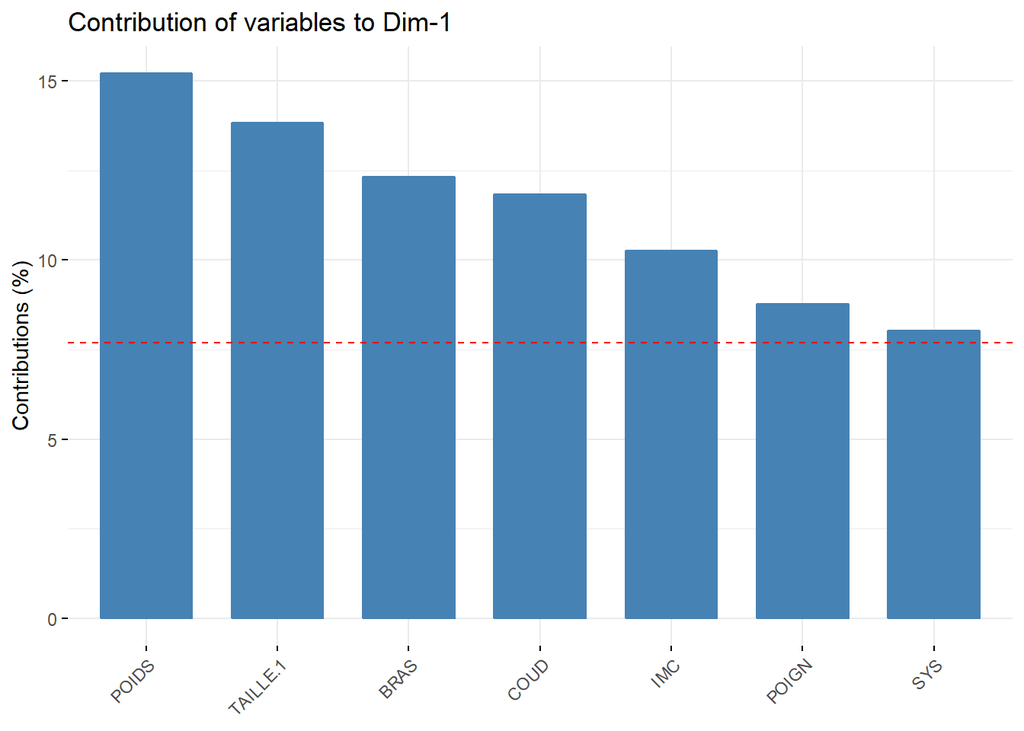

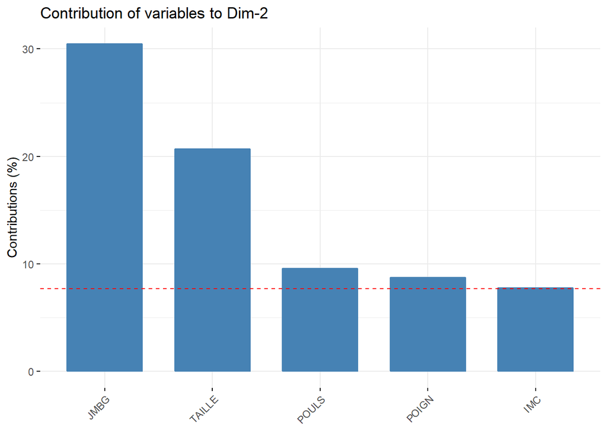

##### Le second axe factoriel est principalement caracterisé par les variables taille de la jambe gauche et taille. L’axe 2 est donc un axe de la taille, il sépare l’ individu 29, assez grand de l’individus 67, assez petit.

##### Un petit groupe d’individus se détache: les individus 56, 57, 63, 50, 47 sont assez semblables et caratérisés par une taille proche de la moyenne et un poids assez faible par rapport à la moyenne des individus.

##### Les individus 62 et 56 sont diamétralement opposés, le premier se caractérise par un poids élevé et une petite taille alors que que le second est assez grand et léger.